# MA710 - New York Times Articles - Data Science

Sevdalena Lazarova

21 Mar 2017

# Introduction

This assignment uses New York Times data made available through its APIs for the purpose of encouraging innnovation through collaboration.The Article Search API announced by New York Times is a way to find, discover, explore millions of articles from 1981 onwards. Each article is comprised of searchable fields such as headline, byline, lead paragraph, publication date and Article ID among others. We request an API key that allows us to retrieve these New York Times articles. The data is returned in JSON format.

# Create the dataset

```r
library(cluster)
library(RCurl)
library(RJSONIO)
library(rlist)
library(stringr)
library(dplyr)
library(magrittr)
library(RTextTools)
library(ngram)
library(SnowballC)
options(dplyr.width=Inf)
articlesearch.key = "80663dd1c295412e867d24982fd695f8"
get.nyt.hits(query.string="Oscar",     # OPTION
             begin.date="20161126",    # OPTION
             end.date  ="20170326")    # OPTION
article.df = get.nyt.articles(pages = -1,
                              query.string = "Oscar",
                              begin.date   = "20161126",
                              end.date     = "20170426")
save(article.df,
     file="C:/Users/sevda/Documents/Bentley/710/Assignment 3/article.df.RData")
```

# Load the dataset

We are loading the saved data frame every time we run or knit the document.

```r
load(file="C:/Users/sevda/Documents/Bentley/710/Assignment 3/article.df.RData")
```

# Base investigation - Iteration 1

[output not shown]

First we are selecting only the lead paragraph from the articles which were extracted from NY Times. The reason we are selecting the lead paragraph is because it contains short and very relevant information to the topic and the content of the corresponding articles.

```r
docs = article.df$lead_paragraph
docs.clean = clean.documents(docs)
docs.sns =
  modify.words(
    docs.clean,
    stem.words=FALSE,  # OPTION: TRUE or FALSE
    ngram.vector=1, # OPTION: n-gram lengths
    stop.words=       # OPTION: stop words
      c(stopwords(kind="english")
        # OPTION: "SMART" or "english"
        # OPTION: additional stop words
      )
  )
doc.matrix <-
  create_matrix(docs.sns,
                language="english",      # Do not change
                stemWords=FALSE,         # Do not change
                removePunctuation=FALSE, # Do not change
                weighting=tm::weightTfIdf   # OPTION: weighting (see below)
  )
dtm = as.matrix(doc.matrix)
dtm=reduce.dtm(dtm,freq.threshold=1)
k = 6
cluster = kmeans(dtm,k)$cluster
```

### Evaluation: cluster counts

The table below indicates the number of articles that are contained in each of our 6 clusters.

```
##   cluster Freq
## 1       1 1172
## 2       2    1
## 3       3    9
## 4       4    1
## 5       5   12
## 6       6    2
```

We can see from the results, that the clusters are very unbalanced. We have cluster 1 as being with more than 1151 articles and cluster 4 and 6 with barely 1 and 2 articles in them. Since the results are not satisfactory we will proceed with another iteration in which we will change some of the parameters.

# Base investigation - Iteration 2

Before we perform further clustering, we will select the optimal number of clusters by using the clValid function to select the optimal number of clusters.

```r
library(clValid)
clValid.result = clValid(dtm, nClust=2:10, clMethods=c("kmeans"), validation='internal', maxitems = nrow(dtm))
print(summary(clValid.result))
```

```
##
## Clustering Methods:
##  kmeans
##
## Cluster sizes:
##  2 3 4 5 6 7 8 9 10
##
## Validation Measures:
##                            2       3       4       5       6       7       8       9      10
##
## kmeans Connectivity   2.9290  5.8579  8.7869 11.7159 14.6448 17.5738 20.5028 20.5028 23.4317
##        Dunn           0.8138  0.7938  0.7803  0.6659  0.6862  0.7081  0.7037  0.6852  0.6954
##        Silhouette     0.5880  0.5466  0.5186  0.4768  0.4681  0.4669  0.4405  0.4513  0.4446
##
## Optimal Scores:
##
##              Score  Method Clusters
## Connectivity 2.9290 kmeans 2
## Dunn         0.8138 kmeans 2
## Silhouette   0.5880 kmeans 2
##
## NULL
```

When we choose the number of clusters, we are looking to maximize Dunn (which values are from 0 to infinity), to minimize Connectivity (which values ranges from 0 to infinity) and to maximize the Silhouette (which has values between 0 to 1). Based on the results, the best option for number of clusters is 2. We will use the kmeans clustering algorithm with number of cluster 2.

[output not shown]

Compared to the first iteration, we are changing only the number of clusters - in this case we will have two clusters instead of the initial 6.

```r
docs = article.df$lead_paragraph
docs.clean = clean.documents(docs)
docs.sns =
  modify.words(
    docs.clean,
    stem.words=FALSE,  # OPTION: TRUE or FALSE
    ngram.vector=1, # OPTION: n-gram lengths
    stop.words=       # OPTION: stop words
      c(stopwords(kind="english")
        # OPTION: "SMART" or "english"
        # OPTION: additional stop words
      )
  )
doc.matrix <-
  create_matrix(docs.sns,
                language="english",      # Do not change
                stemWords=FALSE,         # Do not change
                removePunctuation=FALSE, # Do not change
                weighting=tm::weightTfIdf   # OPTION: weighting (see below)
  )
dtm = as.matrix(doc.matrix)
dtm=reduce.dtm(dtm,freq.threshold=1)
k = 2
set.seed(123)
cluster = kmeans(dtm,k)$cluster
```

### Evaluation: cluster counts

The table below indicates the number of articles that are contained in each cluster.

```
##   cluster Freq
## 1       1    3
## 2       2 1194
```

Since this was the best number of clusters based on the results from the clValid function, we will explore further what are the clusters common words and top words characteristics.

### Evaluation: common words

We will explore the most common words in each of the clusters and whether we can determine a general topic for the given clusters.

```
##           word      avg           word        avg
## 1  [cluster 1]       NA    [cluster 2]         NA
## 2  [3 records]       NA [1194 records]         NA
## 3         mood 2.050046          today 0.03342140
## 4        party 1.534062        history 0.03152341
## 5        cheng 1.136134          oscar 0.02582218
## 6       freddy 1.136134           know 0.02544406
## 7       sneaks 1.136134           need 0.02541481
## 8    hollywood 0.883840            day 0.02435558
## 9       ã³scar 0.000000           film 0.02265763
## 10         abc 0.000000         awards 0.02247913
## 11         abe 0.000000            new 0.02199572
## 12     ability 0.000000           will 0.01903168
```

Based on the results, we can see that cluster 2 is a mix of various articles without a common theme to them. While cluster 1 focuses on articles which focus on “mood”, “party”, “Cheng” and “Hollywood”.

We can perform a more focused exploration of the top words in each clusters, however we expect the results are similar to what we have already observed.

```
##           word      avg
## 1  [cluster 1]       NA
## 2  [3 records]       NA
## 3         mood 2.050046
## 4        party 1.534062
## 5        cheng 1.136134
## 6       freddy 1.136134
## 7       sneaks 1.136134
## 8    hollywood 0.883840
## 9       ã³scar 0.000000
## 10         abc 0.000000
## 11         abe 0.000000
## 12     ability 0.000000
```

```
##              word        avg
## 1     [cluster 2]         NA
## 2  [1194 records]         NA
## 3           today 0.03342140
## 4         history 0.03152341
## 5           oscar 0.02582218
## 6            know 0.02544406
## 7            need 0.02541481
## 8             day 0.02435558
## 9            film 0.02265763
## 10         awards 0.02247913
## 11            new 0.02199572
## 12           will 0.01903168
```

Again we can see the more focused topics of the articles in Cluster 1 which relate to the Oscar party and overall the emotions around the Oscars while the second cluster is a mix of different topics.

### Evaluation: check documents

We will have a look at the first 10 of the articles in Cluster 1 and we can see that the topics are really about the party, Fredy Chend and Hollywood.

```
## [1] "Freddy Cheng sneaks up on us."
## [2] "Is Hollywood in the mood to party?"
## [3] "Is Hollywood in the mood to party?"
```

Based on our evaluation so far and the lack of satisfactory clustering results, we will look further into forming clusters by changing the weighting method from weightTfIdf (inverse document frequency) to term frequency.

# Base investigation - Iteration 3

We are starting with similar parameters as in Iteration 2, however this time will use the term frequency weighting method to see whether we will be able to notice any significant difference in the results.

[output not shown]

```r
docs = article.df$lead_paragraph
docs.clean = clean.documents(docs)
docs.sns =
  modify.words(
    docs.clean,
    stem.words=FALSE,  # OPTION: TRUE or FALSE
    ngram.vector=1, # OPTION: n-gram lengths
    stop.words=       # OPTION: stop words
      c(stopwords(kind="english")
        # OPTION: "SMART" or "english"
        # OPTION: additional stop words
      )
  )
doc.matrix <-
  create_matrix(docs.sns,
                language="english",      # Do not change
                stemWords=FALSE,         # Do not change
                removePunctuation=FALSE, # Do not change
                weighting=tm::weightTf   # OPTION: weighting (see below)
  )
dtm = as.matrix(doc.matrix)
dtm=reduce.dtm(dtm,freq.threshold=1)
```

Before we perform further clustering, we will select the optimal number of clusters by using the clValid function to select the optimal number of clusters.

```r
library(clValid)

clValid.result = clValid(dtm, nClust=2:10, clMethods=c("kmeans"), validation='internal', maxitems = nrow(dtm))
print(summary(clValid.result))
```

```
##
## Clustering Methods:
##  kmeans
##
## Cluster sizes:
##  2 3 4 5 6 7 8 9 10
##
## Validation Measures:
##                             2        3        4        5        6        7        8        9       10
##
## kmeans Connectivity    3.8579   6.7869   9.7159  13.5738  19.4317  23.2897  29.1476 743.8135 743.8135
##        Dunn            0.7208   0.7445   0.7548   0.7454   0.7159   0.6982   0.6977   0.2294   0.2294
##        Silhouette      0.3490   0.3434   0.3217   0.2938   0.2695   0.2571   0.2526   0.0425   0.0427
##
## Optimal Scores:
##
##              Score  Method Clusters
## Connectivity 3.8579 kmeans 2
## Dunn         0.7548 kmeans 4
## Silhouette   0.3490 kmeans 2
##
## NULL
```

When we choose the number of clusters, we are looking to maximize Dunn (which values are from 0 to infinity), to minimize Connectivity (which values ranges from 0 to infinity) and to maximize the Silhouette (which has values between 0 to 1). Based on the results, the best option for number of clusters is 2. We will use the kmeans clustering algorithm with number of cluster 2.

```r
k = 2
set.seed(123)
cluster = kmeans(dtm,k)$cluster
```

### Evaluation: cluster counts

The table below indicates the number of articles that are contained in each cluster.

```
##   cluster Freq
## 1       1 1083
## 2       2  114
```

Again we can see that the clusters are relatively unbalanced. We have an enormous cluster 1 which contains 1083 of the articles and cluster 2 which contains barely 114 articles.

Since this was the best number of clusters based on the results from the clValid function, we will explore further what are the clusters’ common words and top words characteristics.

### Evaluation: common words

We will explore the most common words in each of the clusters and whether we can determine a genral topic for the given clusters.

```
##              word        avg          word        avg
## 1     [cluster 1]         NA   [cluster 2]         NA
## 2  [1083 records]         NA [114 records]         NA
## 3           oscar 0.16897507           new 1.00000000
## 4            film 0.11265005          york 0.33333333
## 5          awards 0.10249307          film 0.12280702
## 6       president 0.10064635         oscar 0.12280702
## 7            best 0.08956602          year 0.11403509
## 8           trump 0.08494922          city 0.09649123
## 9            will 0.07663897         first 0.09649123
## 10           year 0.07663897          best 0.08771930
## 11        academy 0.07294552          week 0.08771930
## 12         sunday 0.07109880      director 0.07894737
```

Based on the results, we can see that cluster 1 is a mixed of various articles without a common theme to theme. While cluster 2 focuses on articles which mention New York as a focus.

We can perform a more focused exploration of the top words in each clusters, however the results are similar to what we have already observed.

```
##              word        avg
## 1     [cluster 1]         NA
## 2  [1083 records]         NA
## 3           oscar 0.16897507
## 4            film 0.11265005
## 5          awards 0.10249307
## 6       president 0.10064635
## 7            best 0.08956602
## 8           trump 0.08494922
## 9            will 0.07663897
## 10           year 0.07663897
## 11        academy 0.07294552
## 12         sunday 0.07109880
```

```
##             word        avg
## 1    [cluster 2]         NA
## 2  [114 records]         NA
## 3            new 1.00000000
## 4           york 0.33333333
## 5           film 0.12280702
## 6          oscar 0.12280702
## 7           year 0.11403509
## 8           city 0.09649123
## 9          first 0.09649123
## 10          best 0.08771930
## 11          week 0.08771930
## 12      director 0.07894737
```

Again we can see the more focused topics of the articles in Cluster 2 which relate to New York.

### Evaluation: check documents

We will have a look at the first 10 of the articles in Cluster 2 and we can see that the topics are really about New York.

```
##  [1] "Philipp Plein comes to New York, Proenza Schouler says farewell, and new designers debut at Oscar de la Renta."
##  [2] "A photo diary of the fall/winter 2017 collections that were presented in New York on Monday."
##  [3] "A three-time Oscar-winning cinematographer is being honored by the George Eastman Museum in Rochester, New York, for his work with such Hollywood icons as Francis Ford Coppola and Warren Beatty."
##  [4] "Nicole Kidman and Isabelle Huppert provided the star wattage of the week, while John Gallianos Maison Margiela gave new meaning to the concept of new look."
##  [5] "Mahershala Ali is celebrating two little new ones."
##  [6] "Mahershala Ali is celebrating two little new ones."
##  [7] "All eyes will be on new Brazilian international signings Oscar and Hulk when big spenders Shanghai SIPG begin their Asian Champions League Group F campaign at FC Seoul on Tuesday."
##  [8] "Antiques, custom furnishings and what the owners say will be the longest bar in New York City fill a space honoring the Irish playwright."
##  [9] "Philipp Plein promised something different for his first turn at New York Fashion Week and delivered with a huge crowd packed into the monolithic main branch of the public library, live music courtesy of Nas and The Kills &#8212; and Madonna turning up last minute on his front row."
## [10] "Upscale fashion company Carolina Herrera is suing rival Oscar de la Renta and a star designer in a New York City breach-of-contract case."
```

# Base investigation - Iteration 4

From our earlier iterations, we decide to keep the weighting as tm::weightTf, since Iteration 3 gave us better clustering results than Iteration 2. So far all our iterations have not considered Stemming. Stemming is the process of reducing words to their base form. For example a stemming algorithm would remove the ‘-ing’ ending of the word ‘jumping’ to get ‘jump’. Thus, any two words that have the same stem but different endings are considered the same word. This process makes the root word more frequent in our term document matrix and could potentially increase its importance to the document. Therefore in this iteration, we allow stemming by setting `stem.words` = TRUE.

[output not shown]

```r
docs = article.df$lead_paragraph
docs.clean = clean.documents(docs)
docs.sns =
  modify.words(
    docs.clean,
    stem.words=TRUE,  # OPTION: TRUE or FALSE
    ngram.vector=1, # OPTION: n-gram lengths
    stop.words=       # OPTION: stop words
      c(stopwords(kind="english")
        # OPTION: "SMART" or "english"
        # OPTION: additional stop words
      )
  )
doc.matrix <-
  create_matrix(docs.sns,
                language="english",      # Do not change
                stemWords=FALSE,         # Do not change
                removePunctuation=FALSE, # Do not change
                weighting=tm::weightTf   # OPTION: weighting (see below)
  )
dtm = as.matrix(doc.matrix)
dtm=reduce.dtm(dtm,freq.threshold=1)
k = 10
set.seed(123)
cluster = kmeans(dtm,k)$cluster
```

### Evaluation: cluster counts

The table below indicates the number of articles that are contained in each cluster.

```
##    cluster Freq
## 1        1   28
## 2        2    2
## 3        3    2
## 4        4   53
## 5        5  717
## 6        6   78
## 7        7    1
## 8        8  130
## 9        9  130
## 10      10   56
```

### Evaluation: common words

```
##            word       avg         word        avg          word        avg
## 1   [cluster 1]        NA  [cluster 4]         NA   [cluster 5]         NA
## 2  [28 records]        NA [53 records]         NA [717 records]         NA
## 3           box 0.7500000          day 0.92452830           new 0.12133891
## 4         offic 0.7500000         know 0.45283019          year 0.10181311
## 5       million 0.5714286         need 0.41509434          film 0.09205021
## 6       weekend 0.4642857        start 0.26415094          will 0.07949791
## 7        disney 0.3928571         week 0.15094340          time 0.05857741
## 8           top 0.3928571          end 0.13207547           one 0.05718271
## 9          anim 0.3571429      reynold 0.13207547          movi 0.05578801
## 10         open 0.2500000          die 0.11320755          star 0.05578801
## 11         earn 0.2142857        carri 0.09433962          play 0.05439331
## 12         film 0.2142857     daughter 0.09433962         first 0.05299861
##            word       avg          word       avg          word        avg
## 1   [cluster 6]        NA   [cluster 8]        NA   [cluster 9]         NA
```

[output cut: 24 more lines]

```
##            word       avg
## 1   [cluster 1]        NA
## 2  [28 records]        NA
## 3           box 0.7500000
## 4         offic 0.7500000
## 5       million 0.5714286
## 6       weekend 0.4642857
## 7        disney 0.3928571
## 8           top 0.3928571
## 9          anim 0.3571429
## 10         open 0.2500000
## 11         earn 0.2142857
## 12         film 0.2142857
```

```
##           word avg
## 1  [cluster 2]  NA
## 2  [2 records]  NA
## 3          age   1
## 4     assassin   1
## 5         back   1
## 6          bay   1
## 7        becom   1
## 8        brink   1
## 9      brought   1
## 10      castro   1
## 11     centuri   1
## 12      commun   1
```

```
##           word avg
## 1  [cluster 3]  NA
## 2  [2 records]  NA
## 3          act   1
## 4        actor   1
## 5    australia   1
## 6          can   1
## 7       cyclon   1
## 8         ever   1
## 9         fact   1
## 10         far   1
## 11        film   1
## 12       first   1
```

```
##             word       avg
## 1    [cluster 8]        NA
## 2  [130 records]        NA
## 3          award 1.0076923
## 4        academi 0.5076923
## 5           film 0.3461538
## 6           best 0.3076923
## 7          oscar 0.2384615
## 8         pictur 0.2307692
## 9         sunday 0.1846154
## 10          land 0.1692308
## 11     hollywood 0.1538462
## 12          year 0.1538462
```

### Evaluation: check documents

```
##  [1] "Disney's witty and relevant \"Zootopia,\" the box-office smash tale of a rural rabbit and a big-city fox who team up to investigate a string of animal disappearances, won the Oscar for best animated feature on Sunday."
##  [2] "There have been monster gorillas and sharp-clawed superheroes at the box office this month, but the biggest beast of them all has been Jordan Peele's $4.5 million, race-exploding thriller \"Get Out.\""
##  [3] "The R-rated \"X-Men\" spinoff \"Logan\" slashed into the weekend box office, opening with a massive $85.3 million in North American theaters, according to studio estimates Sunday, while best-picture winner \"Moonlight\" got a significant, if far from superhero-sized, Oscar bump."
##  [4] "The sequel to all-time box office champion \"Avatar\" has been delayed again and will not be arriving in movie theaters as expected in 2018, director James Cameron has said."
##  [5] "Opening in theaters amid controversy over animal treatment on set and calls for a boycott, \"A Dog's Purpose\" still managed to earn $18.4 million, according to studio estimates Sunday."
##  [6] "\"Logan\" tore into the weekend box office, opening to a massive $85.3 million and proving that moviegoers will show up in force for R-rated comic book movies. The superhero spinoff marks Hugh Jackman's last turn as Wolverine after 17 years of donning the adamantium claws."
##  [7] "The California Institute of the Arts was created partly by Walt Disney's desire to bring more top-flight animators into the profession. And it has during its 47 years, though for a long time almost all were men."
##  [8] "The California Institute of the Arts was created partly by Walt Disney's desire to bring more top-flight animators into the profession. And it has during its 47 years, though for a long time almost all were men."
##  [9] "In 1991, Disney struck gold with \"Beauty and the Beast.\" The film enchanted audiences and critics alike, and raked in several hundred million dollars along the way, but also upended expectations of what an animated film could be."
## [10] "In 1991, Disney struck gold with \"Beauty and the Beast.\" The film enchanted audiences and critics alike, and raked in several hundred million dollars along the way, but also upended expectations of what an animated film could be."
```

```
##  [1] "The outcome of this years election gives Party People, a play now at the Public Theater that draws on the ideas and activism of groups like the Black Panthers and Young Lords, a special urgency."
##  [2] "Embracing Soviet-style communism, Fidel Castro overcame imprisonment and exile to become leader of Cuba and defy the power of the United States at every turn. The strongman's half-century rule was marked by the unsuccessful U.S.-backed Bay of Pigs invasion in 1961 and the Cuban Missile Cris…
##  [3] NA
##  [4] NA
##  [5] NA
##  [6] NA
##  [7] NA
##  [8] NA
##  [9] NA
## [10] NA
```

```
##  [1] "The premiere of \"Tanna,\" Australia's first-ever Oscar nominee for a foreign language film, was as far from Hollywood glamor as one can get. The guests gathered not in an opulent theatre, but in a cyclone-flattened village on a remote island. There were no glittering gowns, but plenty of g…
##  [2] "The premiere of \"Tanna,\" Australia's first-ever Oscar nominee for a foreign language film, was as far from Hollywood glamor as one can get. The guests gathered not in an opulent theater, but in a cyclone-flattened village on a remote island. There were no glittering gowns, but plenty of g…
##  [3] NA
##  [4] NA
##  [5] NA
##  [6] NA
##  [7] NA
##  [8] NA
##  [9] NA
## [10] NA
```

```
##  [1] "The winners of the 89th annual Academy Awards."
##  [2] "The president of the film academy says the two accountants responsible for the best-picture flub at Sunday's Academy Awards will never work the Oscars again. She also laments that the error overshadowed a show that celebrated a rich diversity of talent and storytelling."
##  [3] "Two Iranian hard-line newspapers have criticized Asghar Farhadi's best foreign film Oscar, claiming \"politics\" brought him the award."
##  [4] "Warren Beatty says Academy of Motion Pictures President Cheryl Boone Isaacs should \"publicly clarify\" what happened during Sunday night's best picture presentation \"as soon as possible.\""
##  [5] "The president of the film academy has sent an email to its members telling them they have much to be proud of after this year's Oscars ceremony, and reassuring them changes will be made to avoid a repeat of problems like the botched best-picture announcement that closed the show."
##  [6] "An accountant for the Academy Awards botched the meticulous procedure for announcing the Oscar for best picture when he handed victory to \"La La Land\" before declaring \"Moonlight\" the real winner, PricewaterhouseCoopers (PwC) said on Monday."
##  [7] "This year's Academy Awards are behind us, but J.J. Abrams already has predicted Mark Hamill will be in the running for an Oscar next year for his turn as Luke Skywalker in the next Star Wars film."
##  [8] "The two accountants found at fault for botching the climactic announcement of the winner for best picture at the Academy Awards have been officially declared unfit for any future Oscar duty, organizers of the ceremony said on Wednesday."
##  [9] "Ezra Edelman's nearly eight hour meditation on O.J. Simpson and the culture of race relations in the United States \"O.J.: Made in America\" emerged as the winner of an unusually strong and even thematically similar best documentary category. In his acceptance speech Sunday Edelman dedicate…
## [10] "A look at how the Academy Awards' winners envelopes are handled before being opened live onstage:"
```

## No stemming

We would now like to compare our results wih no stemming. So we set `stem.words` = FALSE.

[output not shown]

```r
docs = article.df$lead_paragraph
docs.clean = clean.documents(docs)
docs.sns =
  modify.words(
    docs.clean,
    stem.words=FALSE,  # OPTION: TRUE or FALSE
    ngram.vector=1, # OPTION: n-gram lengths
    stop.words=       # OPTION: stop words
      c(stopwords(kind="english")
        # OPTION: "SMART" or "english"
        # OPTION: additional stop words
      )
  )
doc.matrix <-
  create_matrix(docs.sns,
                language="english",      # Do not change
                stemWords=FALSE,         # Do not change
                removePunctuation=FALSE, # Do not change
                weighting=tm::weightTf   # OPTION: weighting (see below)
  )
dtm = as.matrix(doc.matrix)
dtm=reduce.dtm(dtm,freq.threshold=2)
k = 10
set.seed(123)
cluster = kmeans(dtm,k)$cluster
```

### Evaluation: cluster counts

The table below indicates the number of articles that are contained in each cluster.

```
##    cluster Freq
## 1        1    2
## 2        2    2
## 3        3   36
## 4        4   45
## 5        5  728
## 6        6   74
## 7        7    2
## 8        8   93
## 9        9   70
## 10      10  145
```

### Evaluation: common words

Again, we would drill down further into the clusters that have a minimum of atleast 20 articles.

```
##            word       avg         word        avg          word        avg
## 1   [cluster 3]        NA  [cluster 4]         NA   [cluster 5]         NA
## 2  [36 records]        NA [45 records]         NA [728 records]         NA
## 3          land 0.9722222          day 0.93333333           new 0.11263736
## 4          best 0.5277778         know 0.48888889          year 0.07005495
## 5         oscar 0.4722222         need 0.48888889          film 0.06868132
## 6        awards 0.4444444        start 0.28888889           one 0.05631868
## 7       musical 0.4166667         week 0.17777778         first 0.04945055
## 8      chazelle 0.3888889         died 0.13333333     president 0.04670330
## 9        damien 0.3888889          end 0.11111111           big 0.04258242
## 10    moonlight 0.3888889      fashion 0.11111111          said 0.04120879
## 11      picture 0.3611111       carrie 0.08888889           top 0.04120879
## 12    hollywood 0.3055556     daughter 0.08888889        league 0.03846154
##            word       avg         word       avg         word        avg
## 1   [cluster 6]        NA  [cluster 8]        NA  [cluster 9]         NA
```

[output cut: 24 more lines]

The clustering results without stemming are very similar to the results for stemming. Clusters 1, 2 and 8 represent the same theme as earlier.

# Base investigation - Iteration 5

The next parameter setting we want to try is to add n-grams. Since from our previous step of base inverstigation, there are names of movies, people and cities appear as common words in the clusters. For example, “Donald” and “Trump”, as well as “New” and “York”. We could use n-grams to modiff the clustering result.

[output not shown]

```r
docs = article.df$lead_paragraph
docs.clean = clean.documents(docs)
docs.sns =
  modify.words(
    docs.clean,
    stem.words=FALSE,  # OPTION: TRUE or FALSE
    ngram.vector=1:3, # OPTION: n-gram lengths
    stop.words=       # OPTION: stop words
      c(stopwords(kind="english")
        # OPTION: "SMART" or "english"
        # OPTION: additional stop words
      )
  )

doc.matrix <-
  create_matrix(docs.sns,
                language="english",      # Do not change
                stemWords=FALSE,         # Do not change
                removePunctuation=FALSE, # Do not change
                weighting=tm::weightTf   # OPTION: weighting (see below)
  )

dtm = as.matrix(doc.matrix)
dtm=reduce.dtm(dtm,freq.threshold=3)
```

After we got the matrix, we go with k-means clustering with 4 clusters.

```r
k = 4
set.seed(127)
cluster = kmeans(dtm,centers= k, iter.max= 100, nstart= 50)$cluster
```

### Evaluation: cluster counts

The table below indicates the number of articles that are contained in each cluster.

```
##   cluster Freq
## 1       1  882
## 2       2   93
## 3       3  164
## 4       4   58
```

We need to explore further with common words.

### Evaluation: common words

We will explore the most common words in each of the clusters and whether we can determine a genral topic for the given clusters.

```
##             word        avg           word       avg            word
## 1    [cluster 1]         NA    [cluster 2]        NA     [cluster 3]
## 2  [882 records]         NA   [93 records]        NA   [164 records]
## 3            new 0.10657596         awards 0.6989247           oscar
## 4           film 0.07369615        academy 0.6021505            film
## 5           will 0.07142857           best 0.6021505       nominated
## 6           year 0.07142857        picture 0.4838710         winning
## 7            one 0.05668934   best.picture 0.4408602            best
## 8           said 0.05555556 academy.awards 0.4193548   oscar.winning
## 9      president 0.05442177           film 0.3010753 oscar.nominated
## 10         first 0.05215420         sunday 0.2580645       hollywood
## 11           day 0.04875283        la.land 0.2365591            land
## 12           top 0.04081633           land 0.2365591            year
##          avg                   word       avg
## 1         NA            [cluster 4]        NA
## 2         NA           [58 records]        NA
## 3  1.0000000                 donald 1.0000000
## 4  0.2073171                  trump 1.0000000
## 5  0.1890244           donald.trump 0.9827586
## 6  0.1463415              president 0.8620690
## 7  0.1402439       president.donald 0.6551724
## 8  0.1341463 president.donald.trump 0.6551724
## 9  0.1280488           us.president 0.3793103
## 10 0.1219512    us.president.donald 0.2931034
## 11 0.1219512                 awards 0.2586207
## 12 0.1219512                    ban 0.2586207
```

Cluster 1 has common words as “film”, “first”, “new”, “day”, “year”. The theme of the cluster is ambiguous and we could only guess it is a collection of articles talks about the Oscars, which makes perfect sense because it it the largest clusters out of four.

Topic of the cluster 3 is about Oscar nominations of the year. From the common words “Oscar nominated”, “best”, “winning” and “hollywood”, we could reasonably conclude that aritcles inside of this cluster mainly talk about Oscar nomination and people may argue which nominatied film would win the reward finally.

Cluster 4 is predominant by U.S. president Donald Trump. There are 58 records inside of the cluster and looks like our president cares about Oscars too, which is not suprising at all.

### Evaluation: check documents

We will have a look at the first 10 of the articles in Cluster 2.

```
##  [1] "The winners of the 89th annual Academy Awards."
##  [2] "A spokeswoman for the PwC auditing firm says the company has hired protection for the two accountants responsible for the best-picture flub at the Oscars."
##  [3] "Even amid the chaotic melee on the Dolby Theatre stage during the infamous best-picture Oscar flub, Ryan Gosling was typically unflappable. While most reacted with shock and confusion, there was the \"La La Land\" star &#8212; cool and bemused &#8212; chuckling on the side of the stage."
##  [4] "The president of the film academy says the two accountants responsible for the best-picture flub at Sunday's Academy Awards will never work the Oscars again. She also laments that the error overshadowed a show that celebrated a rich diversity of talent and storytelling."
##  [5] "Warren Beatty says Academy of Motion Pictures President Cheryl Boone Isaacs should \"publicly clarify\" what happened during Sunday night's best picture presentation \"as soon as possible.\""
##  [6] "The president of the film academy has sent an email to its members telling them they have much to be proud of after this year's Oscars ceremony, and reassuring them changes will be made to avoid a repeat of problems like the botched best-picture announcement that closed the show."
##  [7] "Oscars host Jimmy Kimmel shared his perspective on the show's best-picture gaffe during his Monday monologue on \"Jimmy Kimmel Live !\""
##  [8] "An accountant for the Academy Awards botched the meticulous procedure for announcing the Oscar for best picture when he handed victory to \"La La Land\" before declaring \"Moonlight\" the real winner, PricewaterhouseCoopers (PwC) said on Monday."
##  [9] "This year's Academy Awards are behind us, but J.J. Abrams already has predicted Mark Hamill will be in the running for an Oscar next year for his turn as Luke Skywalker in the next Star Wars film."
## [10] "The two accountants found at fault for botching the climactic announcement of the winner for best picture at the Academy Awards have been officially declared unfit for any future Oscar duty, organizers of the ceremony said on Wednesday."
```

We could find that the second cluster is truly about “La La land” mistakenly named best picture.

And we could also take a look at the first 10 of the articles in Cluster 3:

```
##  [1] "Viola Davis has collected a pile of awards for Fences and is expected to win an Oscar, too. Yet her contenders remain upbeat. They have their reasons."
##  [2] "Taylor Sheridan, 47, quit his journeyman acting career and moved to Wyoming. He is now an Oscar nominee."
##  [3] "For documentaries, original songs boost the chances of taking home an Oscar  and may bring more attention to a movie than any award can."
##  [4] "Philipp Plein comes to New York, Proenza Schouler says farewell, and new designers debut at Oscar de la Renta."
##  [5] "A three-time Oscar-winning cinematographer is being honored by the George Eastman Museum in Rochester, New York, for his work with such Hollywood icons as Francis Ford Coppola and Warren Beatty."
##  [6] "Viola Davis won her first Oscar on Sunday for her supporting role as a long-suffering housewife in the African-American family drama \"Fences.\""
##  [7] "See this years Oscar nominees and make your picks."
##  [8] "With advocacy that relied on outrage but not anger, a group helped win clemency for Oscar López Rivera, the long-imprisoned Puerto Rican nationalist."
##  [9] "Actress Natalie Portman had a great reason for missing Sunday's Oscar ceremony."
## [10] "Two Iranian hard-line newspapers have criticized Asghar Farhadi's best foreign film Oscar, claiming \"politics\" brought him the award."
```

From the documents check, we could conclude that the topic of cluster 3 is the Oscar nomination of 2017. It mathches the clustering result very well.

We could conclude that the clustering method works well for our clusters. We could define the topic of each clusters by simply looking at the top words or common words of the clusters.

# Base investigation - Iteration 6

The next parameter setting we want to adjust is the stop word to improve our clustering results. Since from our previous step of inverstigation 5, there are some words in common in each cluster. For instance, words “year”, “will”, “said” and “one” don’t really tell the main topics of that cluster. We want to eliminate those words and investigate whether the clustering results can be further improved.

[output not shown]

```r
docs = article.df$lead_paragraph
docs.clean = clean.documents(docs)
docs.sns =
  modify.words(
    docs.clean,
    stem.words=FALSE,  # OPTION: TRUE or FALSE
    ngram.vector=1:3, # OPTION: n-gram lengths
    stop.words=       # OPTION: stop words
      c(stopwords(kind="english"), stopwords(kind="SMART")
      )
  )

doc.matrix <-
  create_matrix(docs.sns,
                language="english",      # Do not change
                stemWords=FALSE,         # Do not change
                removePunctuation=FALSE, # Do not change
                weighting=tm::weightTf   # OPTION: weighting (see below)
  )

dtm = as.matrix(doc.matrix)
dtm=reduce.dtm(dtm,freq.threshold=3)
```

The four clusters are still applied and the clustering results are shown below.

```r
k = 4
set.seed(127)
cluster = kmeans(dtm,k)$cluster
```

### Evaluation: cluster counts

The table below indicates the number of articles that are contained in each cluster.

```
##   cluster Freq
## 1       1  892
## 2       2  117
## 3       3   16
## 4       4  172
```

### Evaluation: common words

We will explore the most common words in each of the clusters and whether we can determine a genral topic for the given clusters.

```
##             word        avg                   word       avg
## 1    [cluster 1]         NA            [cluster 2]        NA
## 2  [892 records]         NA          [117 records]        NA
## 3           film 0.07735426                 awards 0.6239316
## 4           year 0.07286996                academy 0.4957265
## 5            day 0.04820628                  trump 0.4700855
## 6      president 0.04708520              president 0.4188034
## 7      hollywood 0.04372197                 donald 0.4102564
## 8          night 0.04035874           donald.trump 0.4102564
## 9            top 0.04035874         academy.awards 0.3931624
## 10           big 0.03923767       president.donald 0.3076923
## 11          time 0.03587444 president.donald.trump 0.3076923
## 12          week 0.03587444                   film 0.2564103
##               word    avg            word       avg
## 1      [cluster 3]     NA     [cluster 4]        NA
## 2     [16 records]     NA   [172 records]        NA
## 3           donald 0.9375           oscar 0.9941860
## 4     donald.trump 0.9375            film 0.2093023
## 5            trump 0.9375       nominated 0.1860465
## 6            meryl 0.7500            land 0.1395349
## 7     meryl.streep 0.7500         winning 0.1395349
## 8        president 0.7500         la.land 0.1279070
## 9           streep 0.7500   oscar.winning 0.1279070
## 10           elect 0.6250       hollywood 0.1220930
## 11 president.elect 0.6250 oscar.nominated 0.1220930
## 12    elect.donald 0.5625            year 0.1162791
```

### Evaluation: check documents

We will have a look at the first 10 of the articles in Cluster 2.

```
##  [1] "The winners of the 89th annual Academy Awards."
##  [2] "The president of the film academy says the two accountants responsible for the best-picture flub at Sunday's Academy Awards will never work the Oscars again. She also laments that the error overshadowed a show that celebrated a rich diversity of talent and storytelling."
##  [3] "Warren Beatty says Academy of Motion Pictures President Cheryl Boone Isaacs should \"publicly clarify\" what happened during Sunday night's best picture presentation \"as soon as possible.\""
##  [4] "The president of the film academy has sent an email to its members telling them they have much to be proud of after this year's Oscars ceremony, and reassuring them changes will be made to avoid a repeat of problems like the botched best-picture announcement that closed the show."
##  [5] "An accountant for the Academy Awards botched the meticulous procedure for announcing the Oscar for best picture when he handed victory to \"La La Land\" before declaring \"Moonlight\" the real winner, PricewaterhouseCoopers (PwC) said on Monday."
##  [6] "This year's Academy Awards are behind us, but J.J. Abrams already has predicted Mark Hamill will be in the running for an Oscar next year for his turn as Luke Skywalker in the next Star Wars film."
##  [7] "The two accountants found at fault for botching the climactic announcement of the winner for best picture at the Academy Awards have been officially declared unfit for any future Oscar duty, organizers of the ceremony said on Wednesday."
##  [8] "A look at how the Academy Awards' winners envelopes are handled before being opened live onstage:"
##  [9] "First-time Oscar host Jimmy Kimmel turned President Donald Trump into a comic foil in absentia at the Academy Awards on Sunday, poking fun at the political tumult roiling the United States and the world since the former reality TV star took office."
## [10] "Long before Barry Jenkins made his way to the podium through the bewildered throng that packed the Dolby Theatre stage at the Academy Awards, he sat in a Toronto hotel room explaining his movie's quiet power."
```

Clearly, the articles mentioned Academy Awards. The topic results truley reflect the core information of articles in that cluster, which means that the clustering results are useful.

And we could also take a look at the first 10 of the articles in Cluster 3:

```
##  [1] "Meryl Streep ushered politics into Hollywood's awards season when she used her Golden Globes acceptance speech to condemn President Donald Trump for what she called his \"instinct to humiliate.\" Stars were even more outspoken at the Screen Actors Guild Awards, held just days after Trump's …
##  [2] "Nicole Kidman says her comments that Americans should support President-elect Donald Trump were merely a statement of her belief in democracy, not an endorsement of the incoming president."
##  [3] "In an emotional speech by turns tearful, defiant and humorous, Meryl Streep doubled down on her harsh criticism of President Donald Trump, and spoke of having become a target since she first took him on in her Golden Globes speech in January."
##  [4] "President-elect Donald Trump took to Twitter on Monday, calling Meryl Streep \"one of the most over-rated actresses in Hollywood\" following her speech Sunday night at the Golden Globe awards."
##  [5] "Donald Trump called Meryl Streep an \"overrated actress\" on Monday after the three-time Oscar winner publicly criticized him for having belittled a disabled journalist."
##  [6] "Actress Meryl Streep earned a lifetime achievement award at the Golden Globes Sunday and in accepting, turned the spotlight away from herself."
##  [7] "\"La La Land\" danced off with seven Golden Globes on Sunday in a ceremony marked by surprises and a stinging indictment by Meryl Streep of U.S. President-elect Donald Trump. "
##  [8] "Broadway star Jennifer Holliday said on Saturday she was pulling out of a concert celebrating the inauguration of President-elect Donald Trump, citing an online article that cast the performance as a \"betrayal\" of her gay and lesbian fans."
##  [9] "Actress Meryl Streep turned a Golden Globe acceptance speech into a scathing attack on U.S. President-elect Donald Trump, saying she had been heartbroken by his imitation of a disabled reporter during his campaign."
## [10] "Actress Meryl Streep turned a Golden Globe acceptance speech into a scathing attack on U.S. President-elect Donald Trump, saying she had been heartbroken by his imitation of a disabled reporter during his campaign."
```

The articles are about the emotional comments from Meryl Streep about president Donald Trump.The meaning shares similar information with our clustering topic results.

We can also take look at the first 10 articles in Cluster 4:

```
##  [1] "Viola Davis has collected a pile of awards for Fences and is expected to win an Oscar, too. Yet her contenders remain upbeat. They have their reasons."
##  [2] "Taylor Sheridan, 47, quit his journeyman acting career and moved to Wyoming. He is now an Oscar nominee."
##  [3] "For documentaries, original songs boost the chances of taking home an Oscar  and may bring more attention to a movie than any award can."
##  [4] "Philipp Plein comes to New York, Proenza Schouler says farewell, and new designers debut at Oscar de la Renta."
##  [5] "A three-time Oscar-winning cinematographer is being honored by the George Eastman Museum in Rochester, New York, for his work with such Hollywood icons as Francis Ford Coppola and Warren Beatty."
##  [6] "Viola Davis won her first Oscar on Sunday for her supporting role as a long-suffering housewife in the African-American family drama \"Fences.\""
##  [7] "See this years Oscar nominees and make your picks."
##  [8] "Even amid the chaotic melee on the Dolby Theatre stage during the infamous best-picture Oscar flub, Ryan Gosling was typically unflappable. While most reacted with shock and confusion, there was the \"La La Land\" star &#8212; cool and bemused &#8212; chuckling on the side of the stage."
##  [9] "With advocacy that relied on outrage but not anger, a group helped win clemency for Oscar López Rivera, the long-imprisoned Puerto Rican nationalist."
## [10] "Actress Natalie Portman had a great reason for missing Sunday's Oscar ceremony."
```

The articles are about the Oscar awards and ceremony. The main topic is picked by our clustering topic result. All in all, the clustering topic results match the actual articles meaning. The clustering results are effective in capturing different topics about Oscar.

### Word Cloud of each cluster

We could use common words by frequency to visualize each cluster.

Firstly, we need to construct a data frame of common word and frequency of each cluster:

```r
cluster_matrix <- check.clusters(cluster, 1)[c(-1,-2),]
col <- c("word1", "freq1", "word2", "freq2", "word3", "freq3", "word4", "freq4")
colnames(cluster_matrix) <- col
cluster_matrix
```

```
##        word1      freq1                  word2     freq2           word3
## 3       film 0.07735426                 awards 0.6239316          donald
## 4       year 0.07286996                academy 0.4957265    donald.trump
## 5        day 0.04820628                  trump 0.4700855           trump
## 6  president 0.04708520              president 0.4188034           meryl
## 7  hollywood 0.04372197                 donald 0.4102564    meryl.streep
## 8      night 0.04035874           donald.trump 0.4102564       president
## 9        top 0.04035874         academy.awards 0.3931624          streep
## 10       big 0.03923767       president.donald 0.3076923           elect
## 11      time 0.03587444 president.donald.trump 0.3076923 president.elect
## 12      week 0.03587444                   film 0.2564103    elect.donald
##     freq3           word4     freq4
## 3  0.9375           oscar 0.9941860
## 4  0.9375            film 0.2093023
## 5  0.9375       nominated 0.1860465
## 6  0.7500            land 0.1395349
## 7  0.7500         winning 0.1395349
## 8  0.7500         la.land 0.1279070
## 9  0.7500   oscar.winning 0.1279070
## 10 0.6250       hollywood 0.1220930
## 11 0.6250 oscar.nominated 0.1220930
## 12 0.5625            year 0.1162791
```

We could build a word cloud based on the frequency: We use `brewer.pal` function to create valid color schemes for th words.

#### Word Cloud of cluster 1:

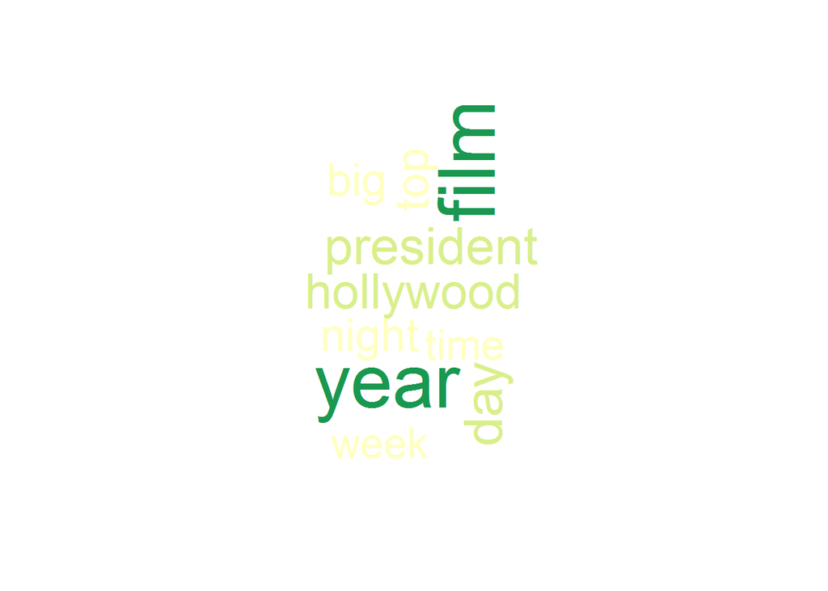

```r
library(wordcloud)
library(RColorBrewer)
pal <- brewer.pal(9, "RdYlGn")
wordcloud(cluster_matrix$word1, cluster_matrix$freq1, colors=pal , rot.per=.3)
```

#### Word Cloud of cluster 2:

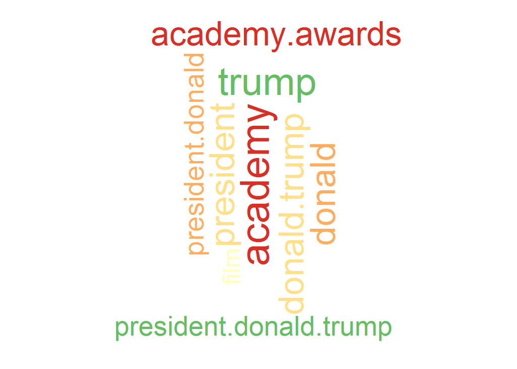

```r
library(wordcloud)
library(RColorBrewer)
wordcloud(cluster_matrix$word2, cluster_matrix$freq2, colors=pal, random.color=TRUE, rot.per=.5)
```

#### Word Cloud of cluster 3:

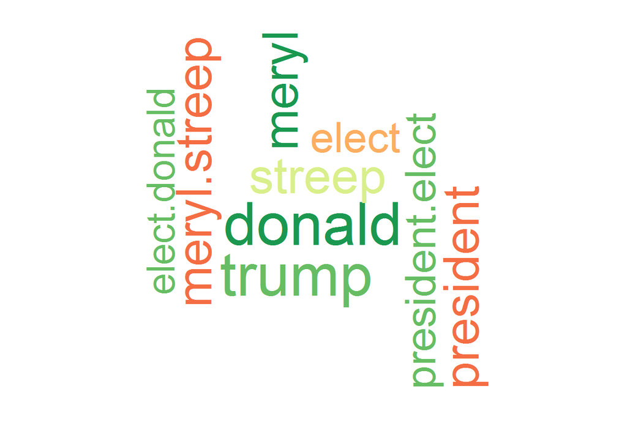

```r
library(wordcloud)
library(RColorBrewer)
wordcloud(cluster_matrix$word3, cluster_matrix$freq3, colors=pal, random.color=TRUE, rot.per=.4)
```

#### Word Cloud of cluster 4:

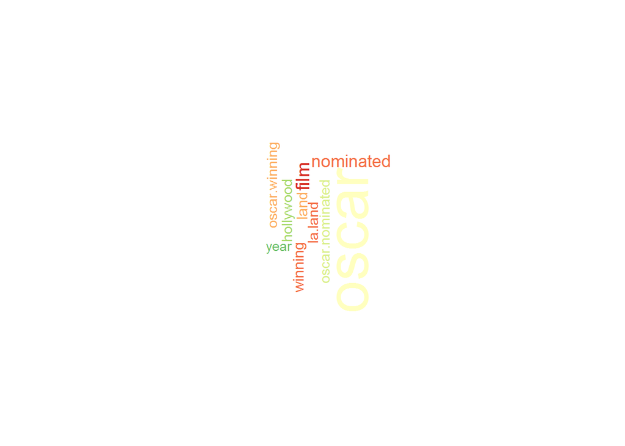

```r
wordcloud(cluster_matrix$word4, cluster_matrix$freq4, colors=pal, random.color=TRUE, rot.per=.5)
```

# Conclusion Based on the clustering analysis, the main topics related to Oscar are Oscar awards and ceremony, emotional comments from Meryl Streep about president Donald Trump, and Academy Awards. The clustering results match the actual article meanings. Our clustering analysis is effective. The further research can include Oscar topics in multiple years to see whether there is any consistency in the popular topics.